# Homework 3

# 5.6.7 Exercises

## (1) 5.6.7 Exercise 1

Brainstorm at least 5 different ways to assess the typical delay characteristics of a group of flights. Consider the following scenarios:

A flight is 15 minutes early 50% of the time, and 15 minutes late 50% of the time.

A flight is always 10 minutes late.

A flight is 30 minutes early 50% of the time, and 30 minutes late 50% of the time.

99% of the time a flight is on time. 1% of the time it’s 2 hours late.

Which is more important: arrival delay or departure delay? Why?

```r
# A flight is 15 minutes early 50% of the time, and 15 minutes late 50% of the time
flights %>%
  group_by(flight) %>%
  summarize(early=sum(arr_delay<=-15, na.rm=TRUE)/n(), late=sum(arr_delay>=15, na.rm=TRUE)/n()) %>%
  filter(early==0.5, late==0.5)
```

```
## # A tibble: 18 × 3
##    flight early  late
##     <int> <dbl> <dbl>
## 1     107   0.5   0.5
## 2    2072   0.5   0.5
## 3    2366   0.5   0.5
## 4    2500   0.5   0.5
## 5    2552   0.5   0.5
## 6    3495   0.5   0.5
## 7    3518   0.5   0.5
## 8    3544   0.5   0.5
## 9    3651   0.5   0.5
## 10   3705   0.5   0.5
## 11   3916   0.5   0.5
## 12   3951   0.5   0.5
## 13   4273   0.5   0.5
## 14   4313   0.5   0.5
## 15   5297   0.5   0.5
## 16   5322   0.5   0.5
## 17   5388   0.5   0.5
## 18   5505   0.5   0.5
```

```r
# A flight is always 10 minutes late
flights %>%
  group_by(flight) %>%
  summarize(late=sum(arr_delay==10, na.rm=TRUE)/n()) %>%
  filter(late==1)
```

```
## # A tibble: 4 × 2
##   flight  late
##    <int> <dbl>
## 1   2254     1
## 2   3656     1
## 3   3880     1
## 4   5854     1
```

```r
# A flight is 30 minutes early 50% of the time, and 30 minutes late 50% of the time
flights %>%
  group_by(flight) %>%
  summarize(early=sum(arr_delay<=-30, na.rm=TRUE)/n(), late=sum(arr_delay>=30, na.rm=TRUE)/n()) %>%
  filter(early==0.5, late == 0.5)
```

```
## # A tibble: 3 × 3
##   flight early  late
##    <int> <dbl> <dbl>
## 1   3651   0.5   0.5
## 2   3916   0.5   0.5
## 3   3951   0.5   0.5
```

```r
# 99% of the time a flight is on time. 1% of the time it's 2 hours late.
flights %>%
  group_by(flight) %>%
  summarize(on_time=sum(arr_delay==0, na.rm=TRUE)/n(), late=sum(arr_delay>=120, na.rm=TRUE)/n()) %>%
  filter(on_time==.99, late == .01)
```

```
## # A tibble: 0 × 3
## # ... with 3 variables: flight <int>, on_time <dbl>, late <dbl>
```

This is really a subjective question to answer since it depends on the one’s personal preferences to answer honestly. I can see arguments for both sides.

## (2) 5.6.7 Exercise 3

Our definition of cancelled flights (is.na(dep_delay) | is.na(arr_delay)) is slightly suboptimal. Why? Which is the most important column?

All flights that arrived also departed, so we can use !is.na(dep_delay).

## (3) 5.6.7 Exercise 4

Look at the number of cancelled flights per day. Is there a pattern? Is the proportion of cancelled flights related to the average delay?

```r
flights %>%
  filter(is.na(dep_delay)) %>%
  count(day)
```

```
## # A tibble: 31 × 2
##      day     n
##    <int> <int>
## 1      1   246
## 2      2   250
## 3      3   109
## 4      4    82
## 5      5   226
## 6      6   296
## 7      7   318
## 8      8   921
## 9      9   593
## 10    10   535
## # ... with 21 more rows
```

```r
flights %>%
  group_by(day) %>%
  summarize(prop_can=sum(is.na(dep_delay))/n(), avg_del=mean(dep_delay, na.rm=TRUE))
```

```
## # A tibble: 31 × 3
##      day    prop_can   avg_del
##    <int>       <dbl>     <dbl>
## 1      1 0.022290685 14.172660
## 2      2 0.023131014 14.115552
## 3      3 0.009722594 10.811295
## 4      4 0.007414775  5.789651
## 5      5 0.020814146  7.820824
## 6      6 0.026765530  6.990244
## 7      7 0.028948566 14.339177
## 8      8 0.081714134 21.760773
## 9      9 0.054619140 14.644680
## 10    10 0.047652979 18.300505
## # ... with 21 more rows
```

## (4) 5.6.7 Exercise 6

For each plane, count the number of flights before the first delay of greater than 1 hour.

```r
flights %>%
  group_by(tailnum) %>%
  mutate(row_num=row_number()) %>%
  filter(arr_delay>60) %>%
  summarize(first_hr_del=first(row_num)-1)
```

```
## # A tibble: 3,371 × 2
##    tailnum first_hr_del
##      <chr>        <dbl>
## 1   D942DN            0
## 2   N0EGMQ            0
## 3   N10156            9
## 4   N102UW           33
## 5   N104UW            6
## 6   N10575            0
## 7   N105UW           34
## 8   N107US           29
## 9   N108UW            9
## 10  N109UW           15
## # ... with 3,361 more rows
```

This uses a grouped summary operation. First I group by plane (tailnum), then I create a variable that defines the row number within each plane. I then filter the data to only include flights with delays longer than an hour, and use summarize() in conjunction with first() to find for each plane the row_num of the first flight with an 1+ hour delay. I subtract 1 from that value to count the number of flights before the first delay, rather than including the first flight with the hour or more delay.

# 5.7.1 Exercises

## (5) 5.7.1 Exercise 2

Which plane (tailnum) has the worst on-time record?

Here I define “on-time” as arriving within 30 minutes of the scheduled arrival time.

```r
flights %>%
  group_by(tailnum) %>%
  summarize(prop_on_time = sum(arr_delay <= 30, na.rm = TRUE) / n(),
            mean_arr_delay = mean(arr_delay, na.rm = TRUE),
            flights = n()) %>%
  arrange(prop_on_time, desc(mean_arr_delay))
```

```
## # A tibble: 4,044 × 4
##    tailnum prop_on_time mean_arr_delay flights
##      <chr>        <dbl>          <dbl>   <int>
## 1   N844MH            0            320       1
## 2   N911DA            0            294       1
## 3   N922EV            0            276       1
## 4   N587NW            0            264       1
## 5   N851NW            0            219       1
## 6   N928DN            0            201       1
## 7   N7715E            0            188       1
## 8   N654UA            0            185       1
## 9   N427SW            0            157       1
## 10  N136DL            0            146       1
## # ... with 4,034 more rows
```

## (6) 5.7.1 Exercise 3

What time of day should you fly if you want to avoid delays as much as possible?

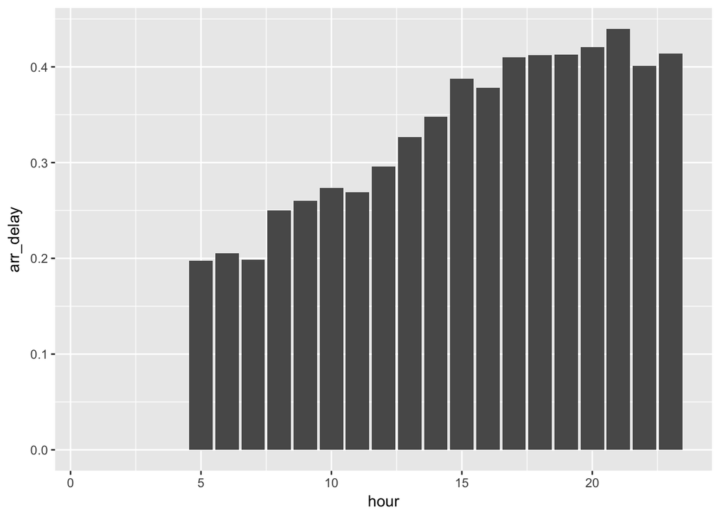

```r
flights %>%
  group_by(hour) %>%
  summarize(arr_delay = sum(arr_delay > 5, na.rm = TRUE) / n()) %>%
  ggplot(aes(x = hour, y = arr_delay)) +
  geom_col()
```

Avoid flying in the evening to minimize your arrival delay.

## (7) 5.7.1 Exercise 5

Delays are typically temporally correlated: even once the problem that caused the initial delay has been resolved, later flights are delayed to allow earlier flights to leave. Using lag(), explore how the delay of a flight is related to the delay of the immediately preceding flight.

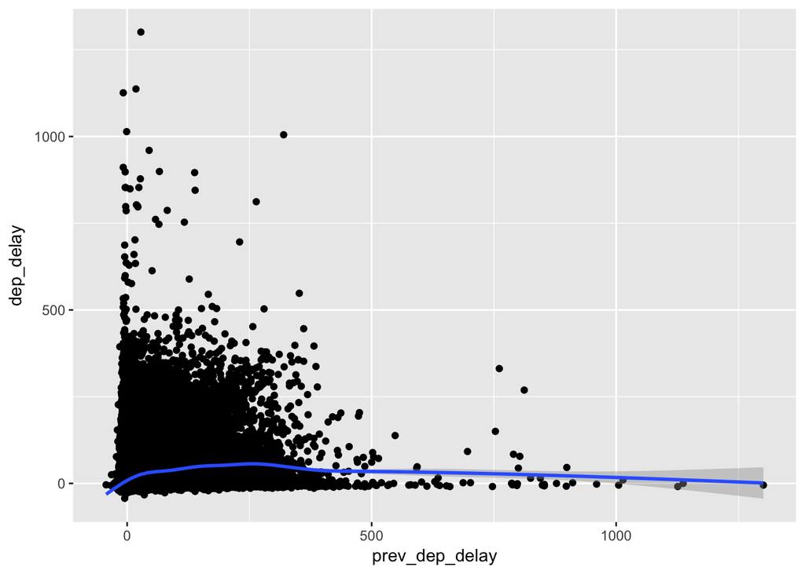

```r
flights %>%
  group_by(origin) %>%
  arrange(year, month, day, hour, minute) %>%
  mutate(prev_dep_delay = lag(dep_delay)) %>%
  ggplot(aes(x = prev_dep_delay, y = dep_delay)) +
  geom_point() +
  geom_smooth()
```

# 7.3.4 Exercises

## (8) 7.3.4 Exercise 1

Explore the distribution of each of the x, y, and z variables in diamonds. What do you learn? Think about a diamond and how you might decide which dimension is the length, width, and depth.

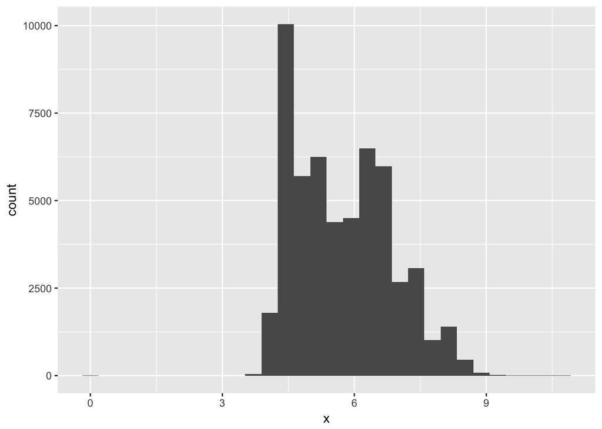

```r
ggplot(diamonds, aes(x)) +
  geom_histogram()
```

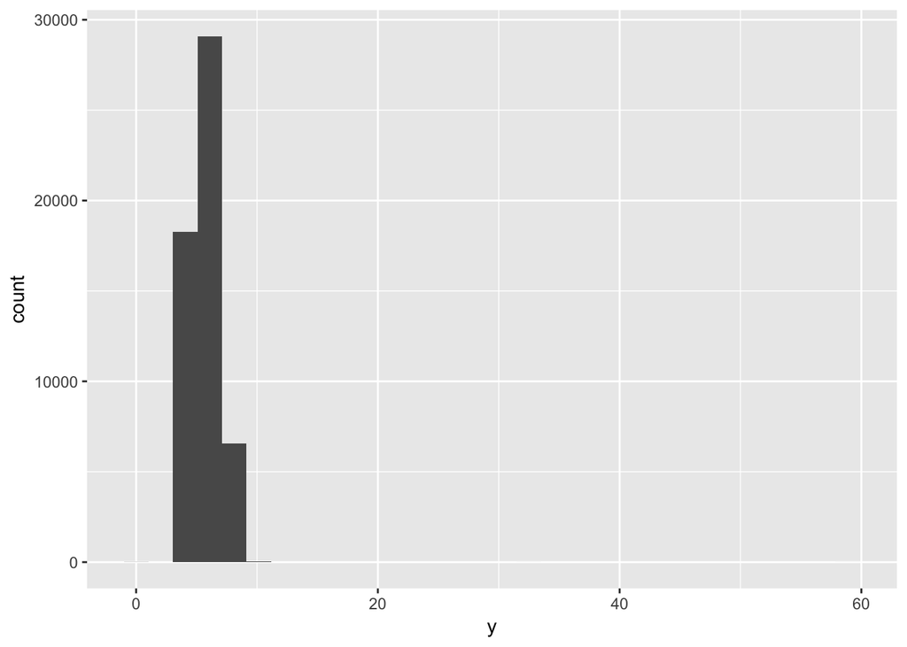

```r
ggplot(diamonds, aes(y)) +
  geom_histogram()
```

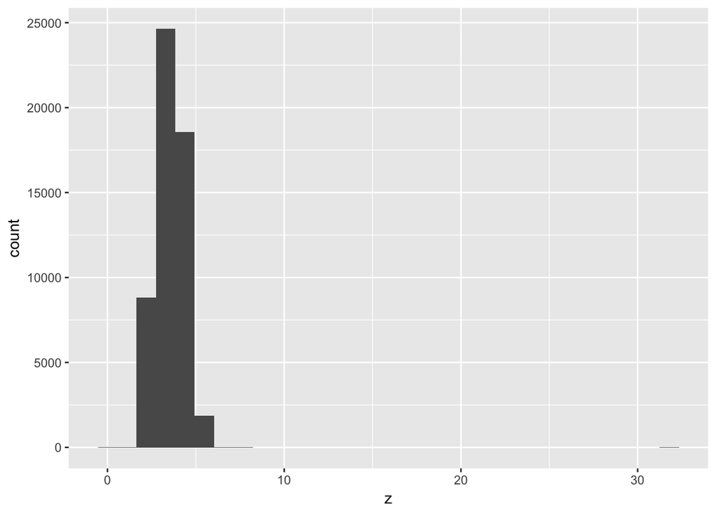

```r
ggplot(diamonds, aes(z)) +
  geom_histogram()
```

## (9) 7.3.4 Exercise 3

How many diamonds are 0.99 carat? How many are 1 carat? What do you think is the cause of the difference?

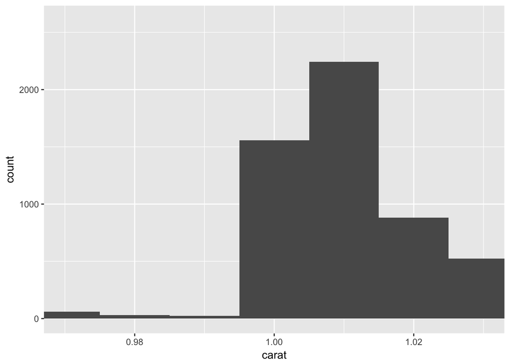

```r
ggplot(diamonds, aes(carat)) +
  geom_histogram(binwidth = .01) +
  coord_cartesian(xlim = c(.97, 1.03))
```

Around 1500 diamonds are 1.00 carat, compared to around 30 or so diamonds at .99 carat. This could occur because prospective buyers of diamonds, if they are already willing to buy a .99 carat diamond will decide it is more aesthetically pleasing to say they bought a 1 carat diamond so there is less demand for .99 carat diamonds.

## (10) 7.3.4 Exercise 4

Compare and contrast coord_cartesian() vs xlim() or ylim() when zooming in on a histogram. What happens if you leave binwidth unset? What happens if you try and zoom so only half a bar shows?

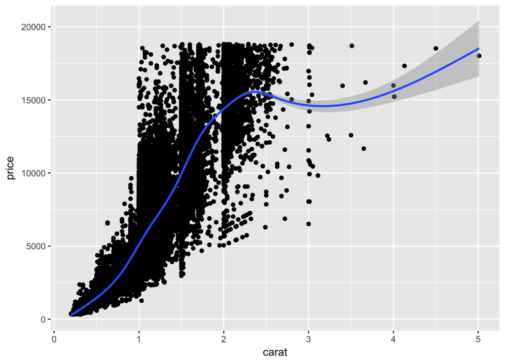

```r
# full plot
ggplot(diamonds, aes(carat, price)) +
  geom_point() +
  geom_smooth()
```

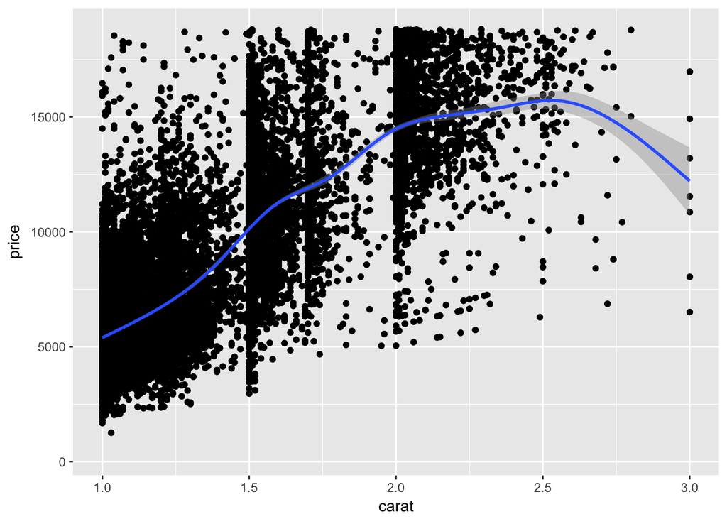

```r
# xlim
ggplot(diamonds, aes(carat, price)) +
  geom_point() +
  geom_smooth() +
  xlim(1, 3)
```

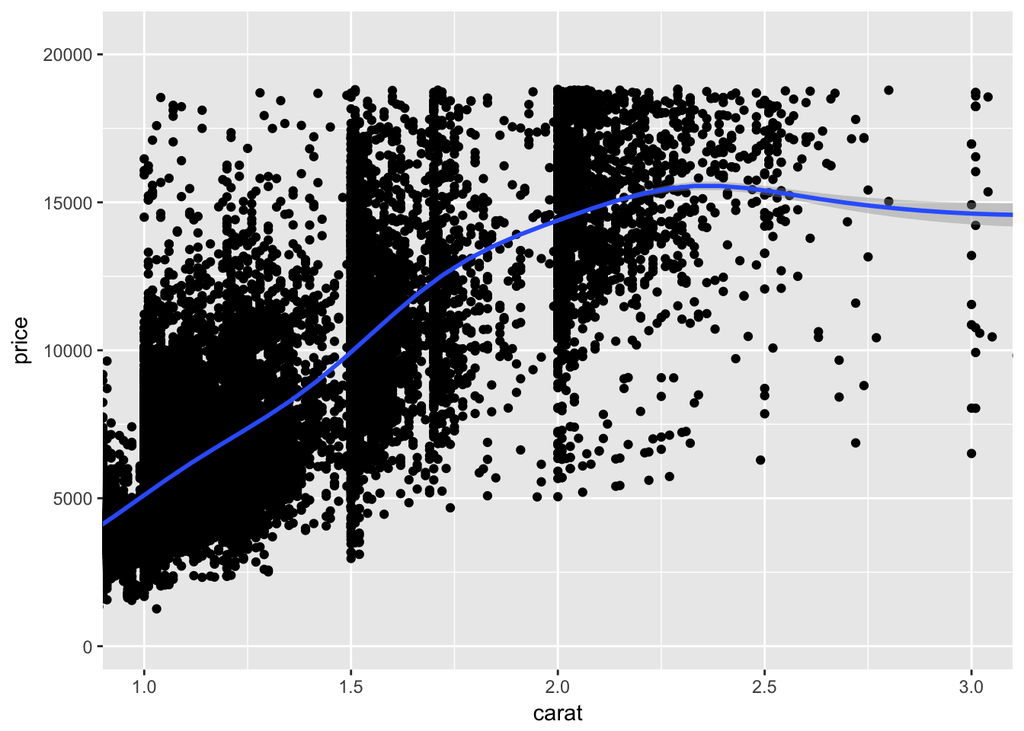

```r
# coord_cartesian
ggplot(diamonds, aes(carat, price)) +
  geom_point() +
  geom_smooth() +
  coord_cartesian(xlim = c(1, 3))
```

By using xlim() or ylim(), you remove all observations which exceed these values so they are not used to generate the plot. By using coord_cartesian(), those values are used to generate the plot and are merely cut off when zooming in. Note the change in the smoothing line in the xlim() example because it doesn’t have all the data points to calculate the line.

# 7.4.1 Exercises

## (11) 7.4.1 Exercise 1

What happens to missing values in a histogram? What happens to missing values in a bar chart? Why is there a difference?

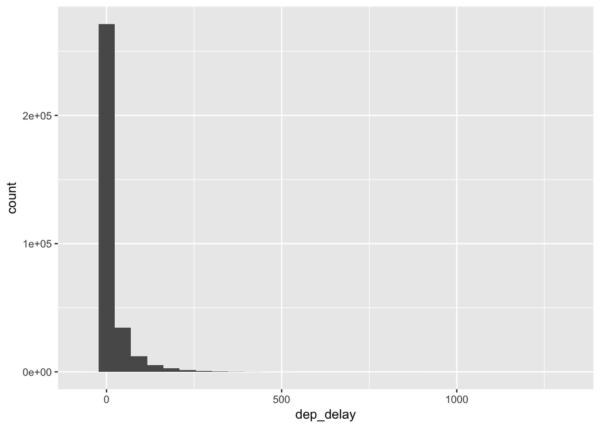

```r
ggplot(flights, aes(dep_delay)) +
  geom_histogram()
```

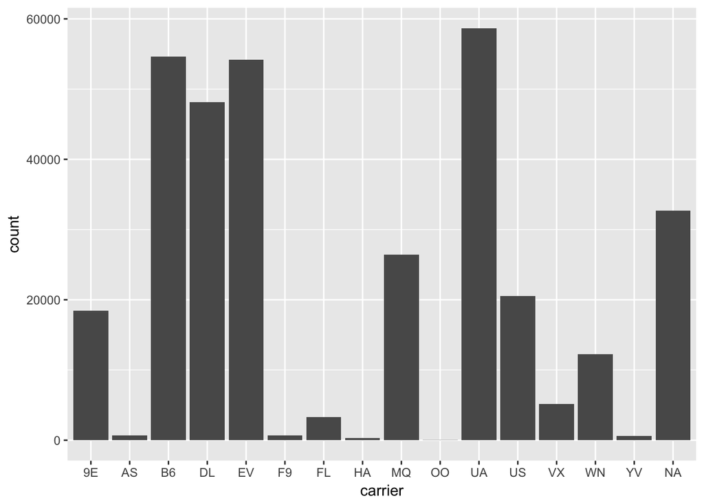

```r
# change AA to NA
flights %>%
  mutate(carrier = ifelse(carrier == "AA", NA, carrier)) %>%
  ggplot(aes(carrier)) +
  geom_bar()
```

Histograms omit missing values, whereas bar charts draw them as a separate category. For continuous variables, like in a histogram, there is no meaningful location to draw missing values. On the far left? Far right? Middle? But for bar charts, which are used for categorical variables, you could draw them as a distinct bar; by default it can be located anywhere on the chart (conventionally it is drawn on the right side). You can override this default to completely remove missing values from the chart if you prefer.

## (12) 7.4.1 Exercise 2

What does na.rm = TRUE do in mean() and sum()?

It strips missing values before computing the statistic.

# 7.5.1.1 Exercises

## (13) 7.5.1.1 Exercise 1

Use what you’ve learned to improve the visualization of the departure times of cancelled vs. non-cancelled flights.

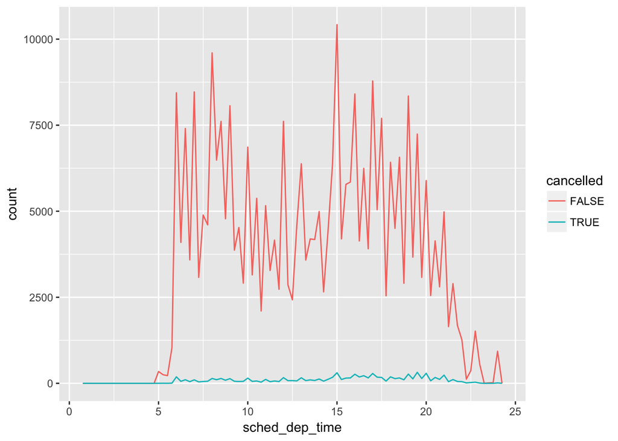

```r
# original chart
flights %>%
  mutate(
    cancelled = is.na(dep_time),
    sched_hour = sched_dep_time %/% 100,
    sched_min = sched_dep_time %% 100,
    sched_dep_time = sched_hour + sched_min / 60
    ) %>%
  ggplot(mapping = aes(sched_dep_time)) +
  geom_freqpoly(mapping = aes(colour = cancelled), binwidth = 1/4)
```

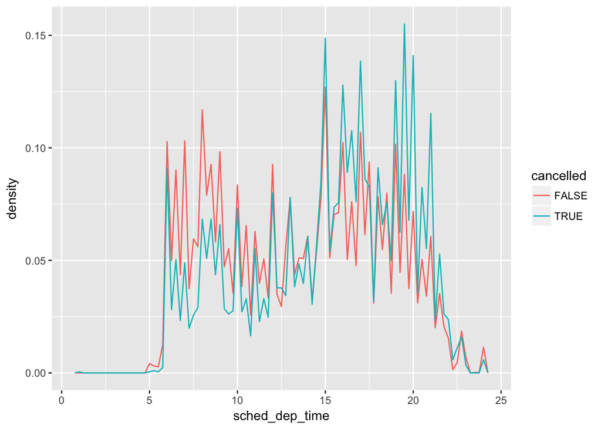

```r
# revised chart
flights %>%
  mutate(
    cancelled = is.na(dep_time),
    sched_hour = sched_dep_time %/% 100,
    sched_min = sched_dep_time %% 100,
    sched_dep_time = sched_hour + sched_min / 60
    ) %>%
  ggplot(aes(x = sched_dep_time, y = ..density.., color = cancelled)) +
  geom_freqpoly(binwidth = 1/4)
```

## (14) 7.5.1.1 Exercise 4

One problem with boxplots is that they were developed in an era of much smaller datasets and tend to display a prohibitively large number of “outlying values”. One approach to remedy this problem is the letter value plot. Install the lvplot package, and try using geom_lv() to display the distribution of price vs cut. What do you learn? How do you interpret the plots?

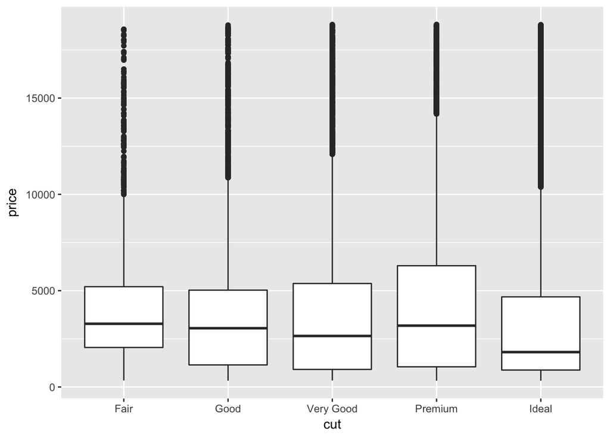

```r
devtools::install_github("hadley/lvplot")
library(lvplot)

# with boxplot
ggplot(diamonds, aes(cut, price)) +
  geom_boxplot()
```

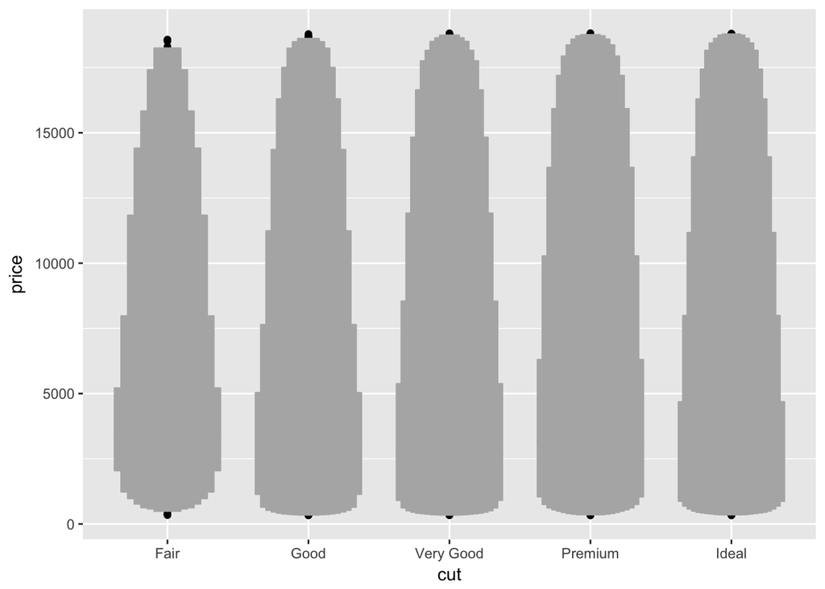

```r
# with lvplot
ggplot(diamonds, aes(cut, price)) +
  geom_lv()
```

# 7.5.2.1 Exercises

## (15) 7.5.2.1 Exercise 1

How could you rescale the count dataset above to more clearly show the distribution of cut within color, or color within cut?

We could use a bar graph to show how the distributions across color and cut compare to one another. This is a very easy way to visualize the difference across this dataset.

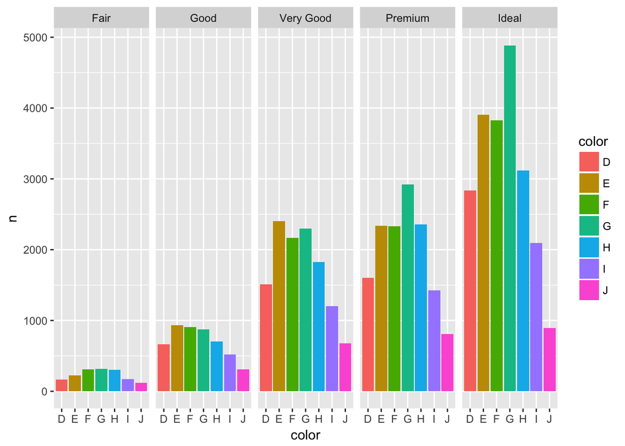

```r
diamonds %>%
  count(color, cut) %>%
  ggplot(mapping = aes(x = color, y = n, fill=color)) +
     geom_col() + facet_grid( ~cut )
```

We could also use geom_raster as it is very similar to geom_tile and add some aesthetic changes that will change the look of the data, but it will not change much about how we interpret it.

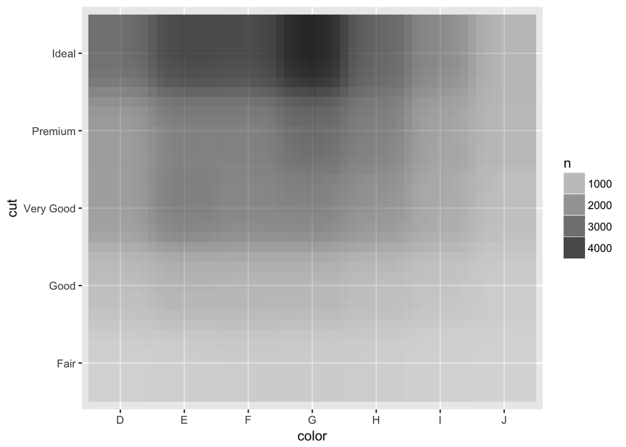

```r
diamonds %>%
  count(color, cut) %>%
  ggplot(mapping = aes(x = color, y = cut)) +
     geom_raster(mapping = aes(alpha = n), interpolate = TRUE)
```

## (16) 7.5.2.1 Exercise 2

Use geom_tile() together with dplyr to explore how average flight delays vary by destination and month of year. What makes the plot difficult to read? How could you improve it?

```r
flights %>%
  select(dep_delay, month, dest)
```

```
## # A tibble: 336,776 × 3
##    dep_delay month  dest
##        <dbl> <int> <chr>
## 1          2     1   IAH
## 2          4     1   IAH
## 3          2     1   MIA
## 4         -1     1   BQN
## 5         -6     1   ATL
## 6         -4     1   ORD
## 7         -5     1   FLL
## 8         -3     1   IAD
## 9         -3     1   MCO
## 10        -2     1   ORD
## # ... with 336,766 more rows
```

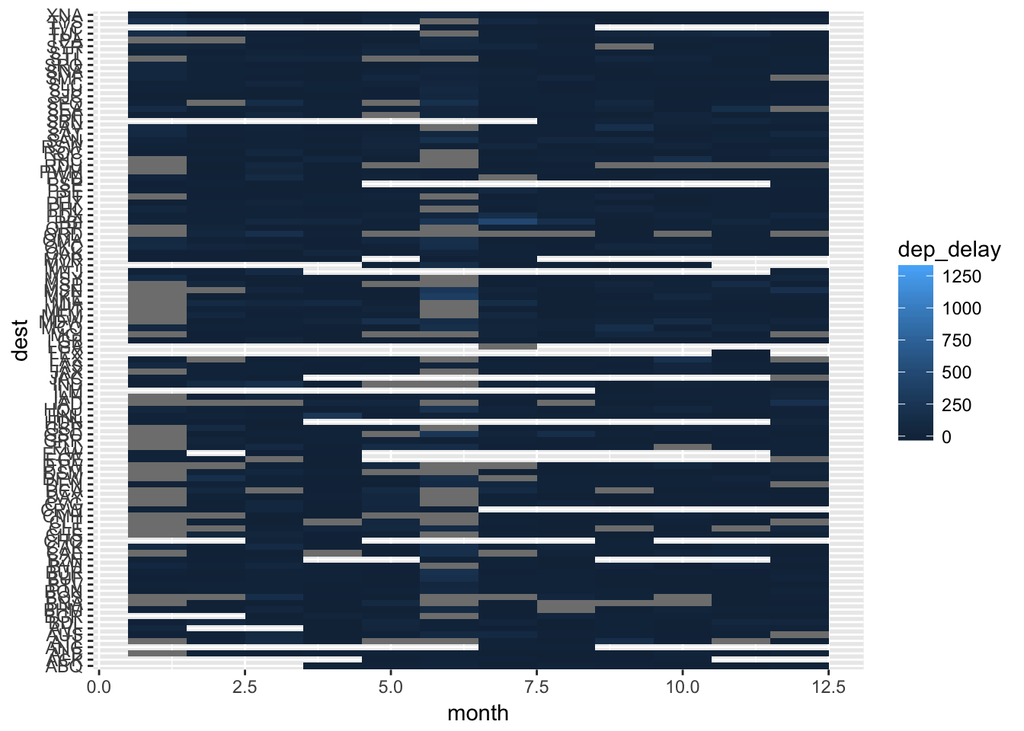

```r
  ggplot(data = flights, mapping = aes(x=month, y=dest)) +
     geom_tile(mapping=aes(fill=dep_delay))
```

This is difficult to read because there are so many destinations that it is difficult to decipher between them. We could improve this by filtering this dataset to only those destinations that met a significant average of departure or arrival delays.

# 7.5.3.1 Exercises

## (17) 7.5.3.1 Exercise 1

Instead of summarizing the conditional distribution with a boxplot, you could use a frequency polygon. What do you need to consider when using cut_width() vs cut_number()? How does that impact a visualization of the 2D distribution of carat and price?

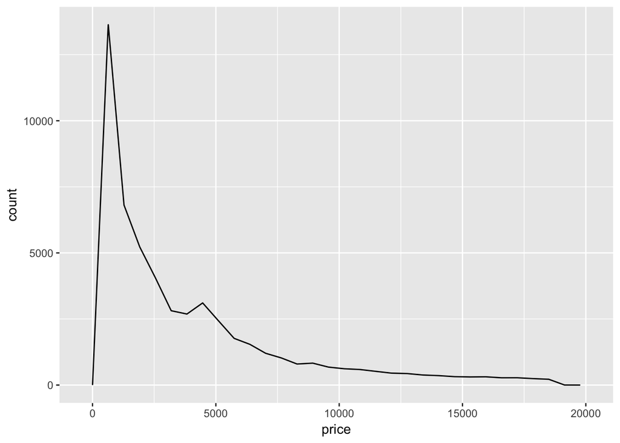

```r
smaller <- diamonds %>% filter(carat < 3)
ggplot(data = smaller) +
   geom_freqpoly(mapping = aes(x=price, group=cut_width(carat, 20)))
```

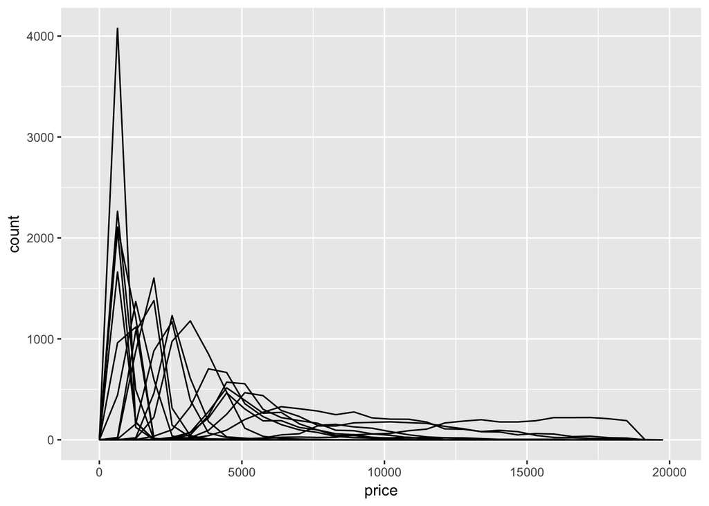

```r
ggplot(data = smaller) +
   geom_freqpoly(mapping = aes(x=price, group=cut_number(carat, 20)))
```

The difference between cut_width and cut_number is that cut_width defines the width of the scale that the groups will be cut into whereas cut_number defines the number of observations that will be in each group. In this case cut_width is giving a width of 20 and cut_number is dividing the dataset into 20 groups of equal number of observations.

## (18) 7.5.3.1 Exercise 2

Visualize the distribution of carat, partitioned by price.

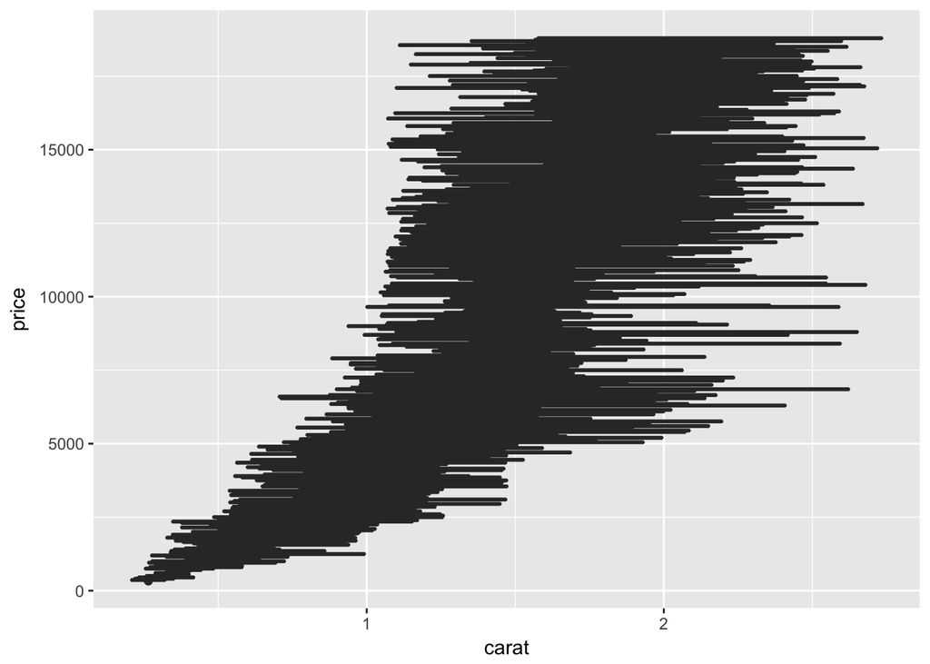

```r
ggplot(data = smaller, mapping = aes(x = carat, price)) +
  geom_boxplot(mapping = aes(group = cut_width(price, 50)))
```

## (19) 7.5.3.1 Exercise 3

How does the price distribution of very large diamonds compare to small diamonds. Is it as you expect, or does it surprise you?

It is as I would expect as the carat gets larger the price also gets larger. As the carat size maximizes, the price drops slightly which is a little surprising.